# Training record

Alber Sánchez

2019-06-13

# Bias and variance

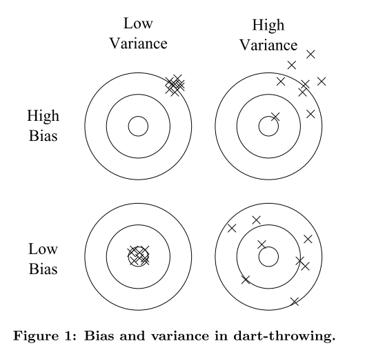

Bias and variance

**One way to understand overfitting is by decomposing generalization error into bias and variance. Bias is a learner’s tendency to consistently learn the same wrong thing. Variance is the tendency to learn random things irrespective of irrespective of the real signal** - (Domingos 2012)

- High bias: High crossvalidation error using a low degree polynomial +There is a high error but training and validation errors are similar.
- High variance: High crossvalidation error using a high degree polynomial
- High variance: There is a big difference between training error and crossvalidation error
- Classification with a HIGH BIAS problem (underfit)
- Training set error is high
- Crossvalidation error is close to the trainng error
- If a leraning algorithm is suffering from high bias, getting more training data will not (by itself) help much
- Classification with a HIGH VARAINCE problem (overfit)
- Training set error is low
- Crossvalidation error is much bigger than the training set error
- If a leraning algorithm is suffering from high variance getting more training data is likely to help
- Fix HIGH BIAS (underfit)
- Try getting additional features (curretn hyppothesis is too simple)
- Try adding polynomial features
- Try decreasing regularization (cost function)
- Fix HIGH VARIANCE (overfit)
- Get more training examples
- Try smaller set of features (the attributes of each sample)
- Try increasing regularization (keep the features but reduce the magnitud/values of the parameters. Works well if there are a lot of features)

Source: Machine Learning — Andrew Ng, Stanford University [FULL COURSE]

# Training

## Experiment summary

**The loss function takes the predictions of the network and the true target (what you wanted the network to output) and computes a distance score, capturing how well the network has done on this specific example.** - (Chollet and Allaire 2018)

**Two quantities are displayed during training: the loss of the network over the training data, and the accuracy of the network over the training data.** - (Chollet and Allaire 2018)

**[The] gap between training accuracy and test accuracy is an example of overfitting** - (Chollet and Allaire 2018)

| Classification_type | Obs_year | Description |
| --- | --- | --- |
| interpolated | 23 | The samples were taken from the bricks of Landsat 8 where the clouds were filled up by interpolation of MXD13 data. The vegetation indexes were recalculated from the bricks of the corresponding bands. |
| starfm | 23 | The samples were taken from the bricks of Landsat 8 where the clouds were filled up by the StarFM mixture model (Landsat 8 - MOD13Q1 mixture model). |
| simple | 4 | The samples were taken from the bricks of the best 4 Landsat 8 images of a year. |
| mask_clouds | 4 | The samples were taken from the bricks of the best 4 Landsat 8 images of a year and the clouds were masked as ‘no_data’. |

| experiment | Clasification_type | labels | bands | Scenes_experiment |
| --- | --- | --- | --- | --- |
| train_20_esensing-006_.R.log | interpolated | forest, deforestation, flood | ndvi, nir, red, swir2 | NA |
| train_21_esensing-007_.R.log | starfm | forest, deforestation, flood | ndvi, nir, red, swir2 | NA |
| train_30_esensing-008_.R.log | interpolated | forest, deforestation, flood | ndvi, nir, red, swir2 | 225063 |
| train_31_esensing-009_.R.log | interpolated | forest, deforestation, flood | ndvi, nir, red, swir2 | 226064 |
| train_32_esensing-010_.R.log | interpolated | forest, deforestation, flood | ndvi, nir, red, swir2 | 233067 |
| train_33_esensing-008_.R.log | starfm | forest, deforestation, flood | ndvi, nir, red, swir2 | 225063 |
| train_34_esensing-009_.R.log | starfm | forest, deforestation, flood | ndvi, nir, red, swir2 | 226064 |
| train_35_esensing-010_.R.log | starfm | forest, deforestation, flood | ndvi, nir, red, swir2 | 233067 |
| train_40_esensing-006_.R.log | simple | forest, deforestation, flood | ndvi, nir, red, swir2 | 225063, 226064, 233067 |
| train_41_esensing-008_.R.log | simple | forest, deforestation | ndvi, nir, red, swir2, vegetation, substrate, dark | 225063, 226064, 233067 |
| train_42_esensing-009_.R.log | simple | forest, deforestation | vegetation, substrate, dark | 225063, 226064, 233067 |
| train_50_esensing-006_.R.log | mask_cloud | forest, deforestation | ndvi, nir, red, swir2 | 225063, 226064, 233067 |
| train_51_esensing-007_.R.log | mask_cloud | forest, deforestation | ndvi, nir, red, swir2, vegetation, substrate, dark | 225063, 226064, 233067 |
| train_52_esensing-008_.R.log | mask_cloud | forest, deforestation | vegetation, substrate, dark | 225063, 226064, 233067 |

## Training results

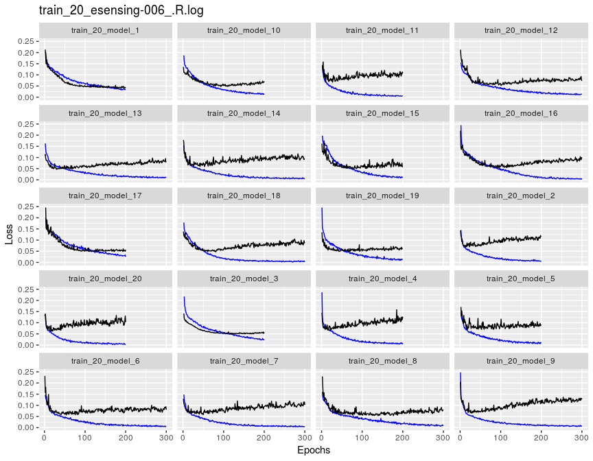

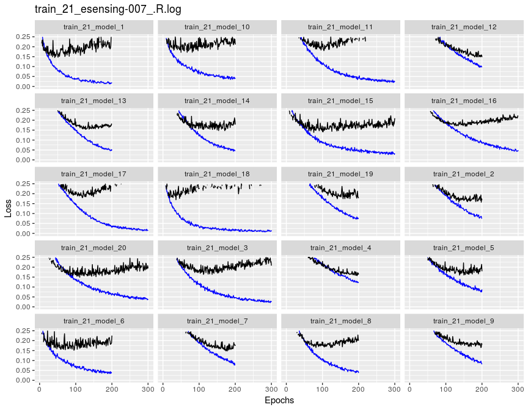

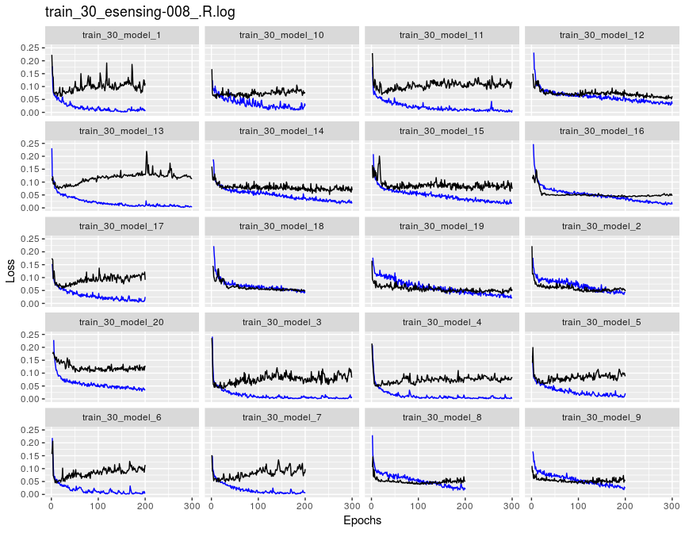

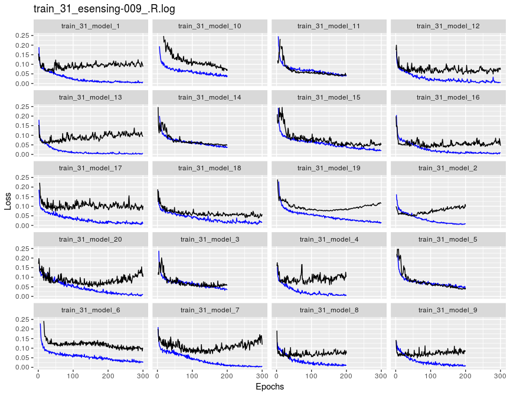

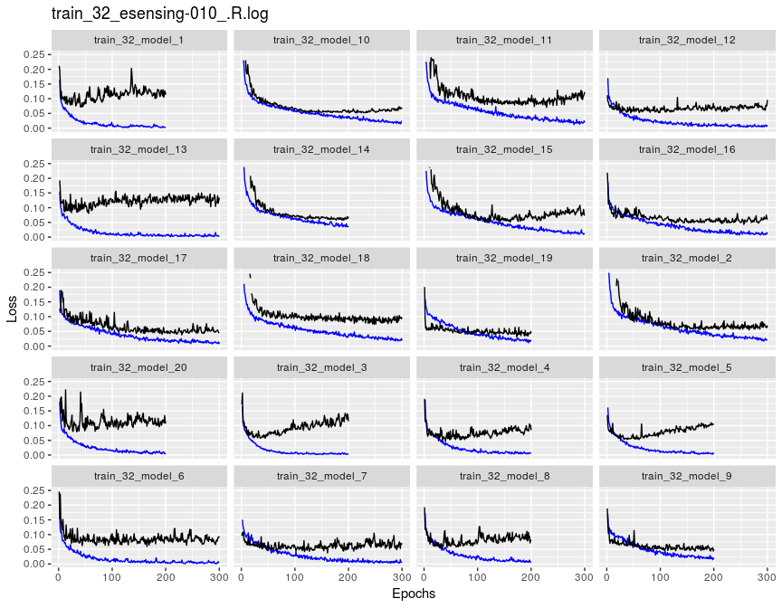

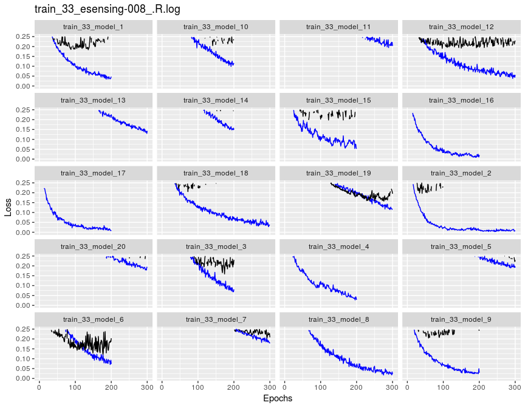

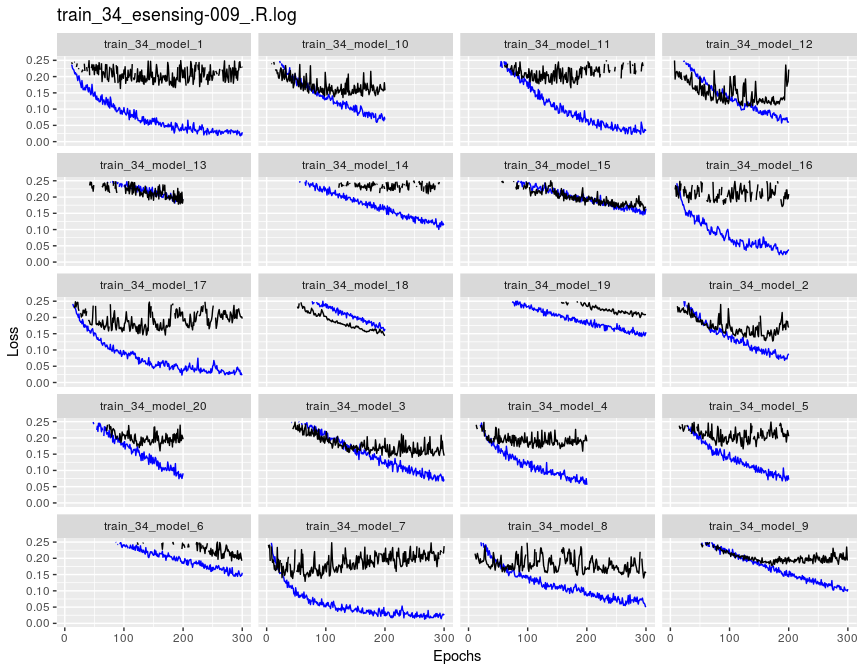

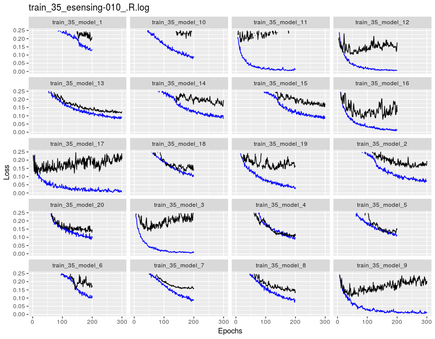

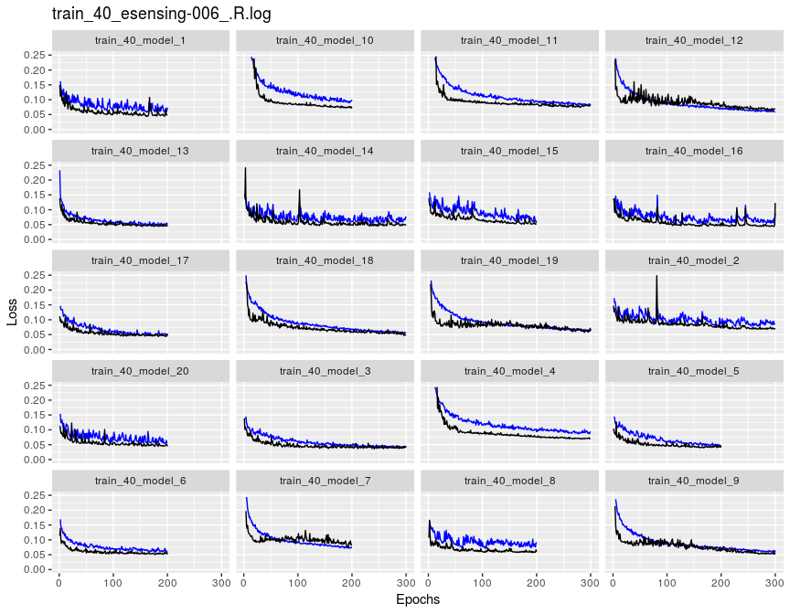

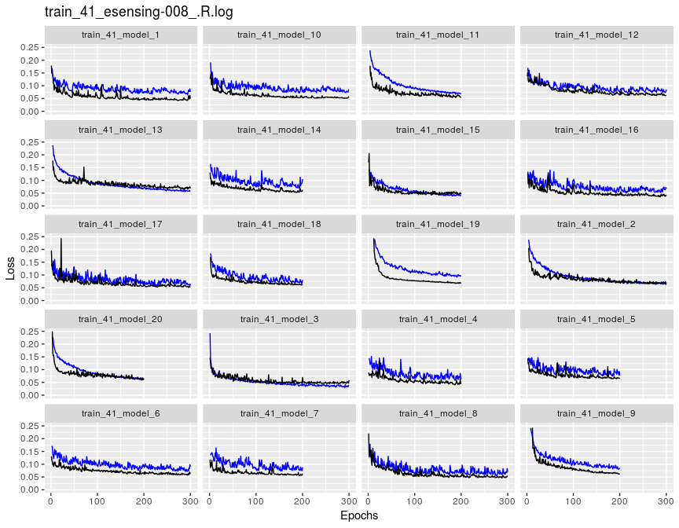

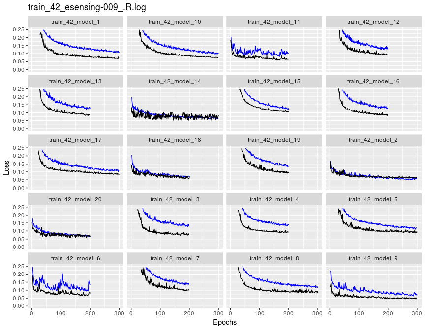

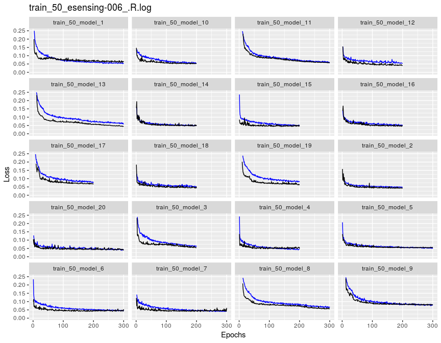

[2 more figures not shown]

## selected trainings

- train_20_model_1
- train_21_model_12
- train_30_model_18
- train_31_model_5
- train_32_model_10
- train_33_model_19
- train_34_model_6
- train_35_model_8
- train_40_model_17
- train_41_model_2
- train_42_model_2
- train_50_model_2
- train_51_model_14
- train_52_model_13

# References

Chollet, Francois, and J.J. Allaire. 2018. *Deep Learning with R*. First. New York City: Manning Publications.

Domingos, Pedro. 2012. “A few useful things to know about machine learning.” *Communications of the ACM* 55 (10): 78. doi:10.1145/2347736.2347755.